```python
%%javascript
IPython.OutputArea.prototype._should_scroll = function(lines) {
    return false;
}
```

```python
# to load images for this tutorial
from IPython.display import Image
import os
path = os.getcwd()
```

# Post Overview.

1. Introduction to \(\chi^{2} \) Goodness-of-Fit Test.
2. Discuss the Assumptions for the \(\chi^{2} \) Goodness-of-Fit Test.
3. \(\chi^{2} \) Goodness-of-Fit Test Formulas.
4. Demonstrate how perform a \(\chi^{2} \) Goodness-of-Fit Test using SPSS.
5. Graphical Overview of \(\chi^{2} \) Goodness-of-Fit Test for Association.

# Introduction to \(\chi^{2} \) Goodness-of-Fit Test.

**\(\chi^{2} \) Goodness-of-Fit Test:**

- Is also called a one-sample goodness-of-fit test or Pearson's chi-square goodness-of-fit test
- Is a test used to determine whether the distribution of cases (instances) in a single categorical variable follow a known or hypothesized distribution.
- The chi-square goodness-of-fit test is a single-sample non parametric test.
- A non parametric test does not assume anything about the underlying distribution of the data. For example, it does not assume the data comes from a normal distribution.
- \(\chi^{2} \) Goodness-of-Fit Test is also often used to evaluate whether sample data is representative of the full population.
- The chi-square goodness-of-fit test is used to compare the observed sample distribution with an expected probability distribution.
- The chi-square goodness-of-fit test let a researcher answer the question: *How well does the model actually reflects the data. How "close" are the observed values to those which would be expected under the fitted model?*
- The Chi-square test is an alternative to the Anderson-Darling and Kolmogorov-Smirnov goodness-of-fit tests (these test can only be used on continuous distributions).
- The Chi-Square Goodness-of-Fit Test can be applied to discrete distributions, such as binomial and Poisson.
- **Key Characteristics of a \(\chi^{2} \) Goodness-of-Fit Test:**
  - **It involves a single variable**.
  - The datatype of the single variable is **Categorical/Nominal**.
  - The test requires that the data first be grouped aka (aggregated as counts and binned).

**Example Case Uses:**

- **Examples:**
  - A hospital administrator wants to plan staffing levels and needs to determine whether there is an equal number of people hospitalized each day.
  - **Variable** Days of week (Monday, Tuesday, Wednesday ... Sunday); categorical data.
  - **Null Hypothesis \(H_{0} \):** The data follows a specified distribution. In this example, the number of people hospitalized on each day are the same.
  - **Alternative Hypothesis \(H_{A} \):** The data does not follows a specified distribution. In this example, the number of people hospitalized is not the same for each day.

**Equal and Unequal proportions and Expected Frequencies.**

**Equal proportions:**

- Chi-square goodness-of-fit test compares observed frequencies in a category of the variable to those frequencies that would be expected if the data followed a known or hypothesized distribution.
- If the known (or hypothesized) distribution has the equal numbers per category of the categorical variable, then this is referred to as a study with **equal proportions**. In other words, *the number of cases in each category will be the same*.
- In a study with equal proportions, the chi-square goodness-of-fit test would be described in terms of the proportion probability, or percentage of cases that would be expected in each category.
- The proportion or probability of a case being in any one of the categories is \(p = \frac{1}{number\ of\ categories} \).

**Unequal proportions:**

- Refer to a chi-square goodness-of-fit test where proportions for each category of the categorical variable are unequal and is referred to as **unequal proportions**.

**Observed versus Expected:**

- The proportions, whether equal or unequal, need to be converted into expected frequencies that can be compared to the observed frequencies.
- This observed frequencies are the number of cases (instances) in each category that are empirically described in the data.
- The expected frequencies are the number of cases (instances) in each category that are expected given the proportion of the known or hypothesized distribution.
- Expected frequencies are calculated as each category proportion is multiplied by the total number of observed cases, and this is described in a subsequent section.

# Discuss the Assumptions for the \(\chi^{2} \) Goodness-of-Fit Test

**Chi-Square Test for Association Assumptions**

In order to run this test, three assumptions must be considered. The first relates to the study design and the last is the characteristic of the data collected. Failure to consider these assumptions can result in misleading and inaccurate conclusions.

# \(\chi^{2} \) Goodness-of-Fit Test Formulas.

**The Chi-Square test statistic**

- For the chi-square goodness-of-fit computation, the data are divided into *k* bins and the test statistic defined as:  
  \[\chi^{2} = \frac{\Sigma_{i=1}^{k}(O_{i} - E_{i})^{2}}{E_{i}} \]  
  \(O_{i} \) is the Observed Frequency for bin *i*  
  \(E_{i} \) is the Expected Frequency for bin *i*  
  and the Expected Frequency is calculated by:  
  \[E_{i} = N(F(Y_{u}) - F(Y_{i})) \]  
  where **F** is the cumulative distribution function for the distribution being tested  
  \(Y_{u} \) is the upper limit for class *i*  
  \(Y_{l} \) is the lower limit for class *i*  
  **N** is the sample size.
- The test is sensitive to the choice of bins.
- The optimal bin width depends on the distribution of the data.
- For the chi-square approximation to be valid, the expected frequency should be at least 5 (assumption 3).
- If some of the counts are less than 5, bins may need to be combined.
- The test is not valid for small samples.

**Critical Region**

- The test statistic follows a chi-square distribution with **(k - c)** degress of freedom.
- **k** is the number of non-empty cells.
- **c** is the number of estimated parameters for the distribution + 1.
- The hypothesis that the data are from a population with the specified distribution is rejected if \( \chi^{2} > \chi^{2}_{1 - \alpha, k - c} \)
- \(\chi^{2}_{1 - \alpha, k - c} \) is the chi-square critical value with k-c degrees of freedom and significance level \(\alpha \)
- A Chi-square probabilities table provides the critical values.

# Demonstrate how perform a \(\chi^{2} \) Goodness-of-Fit Test using SPSS.

#### Steps

1. Case Study.
2. Set up your data.
3. Confirm data does not violate assumptions.
4. Carry out \(\chi^{2} \) Test for Association Procedure.
5. Interpret Results.

### Case Study

- **Project:** An exercise scientist wants to investigate the effects of an exercise-training program mobile application the health of its users.
- **Sample size:** The researcher recruited 100 participants.
- **Categorical Variable:** Body composition ("normal", "overweight", "obese").
- **Aim 1:** The participants' recruitment to the study leads to equal number of individuals in the normal, overweight, and obese groups.
- **Aim 2:** The number of normal, overweight, and obese participants follow the same proportion as those in the population (normal(50%), overweight (35%), obese (15%)).
- The Null hypothesis \(H_{0} \): the observed frequencies for each category are the expected frequencies.
- The Alternative hypothesis \(H_{A}\): the observed frequencies for each category are not the expected frequencies.
- The Level of Significance \(\alpha = 0.05\).

### Step 1: Set up data

**SPSS Variable View**

**SPSS Data View**

- There are 100 instances in this dataset, and the body composition for each instance is described as either 1, 2, or 3.

[figure not shown]

```python
# Variable view
img = os.path.join(path, 'static/images/chisquare/spss1.png')
Image(filename=img,  width = 800)
```

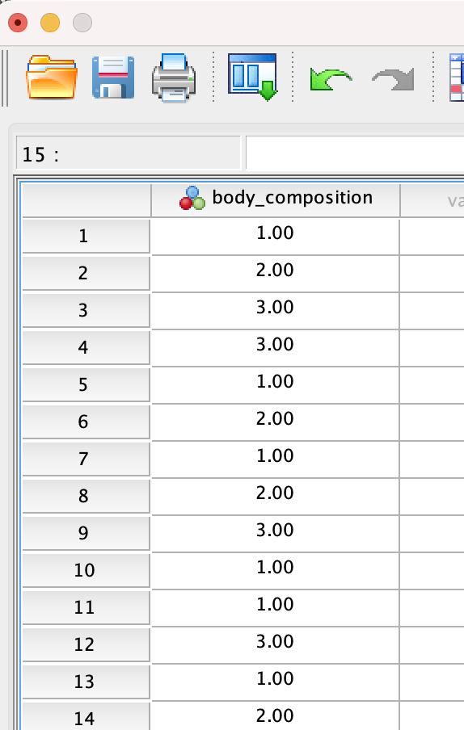

```python
# Data view
img = os.path.join(path, 'static/images/chisquare/spss2.png')
Image(filename=img,  width = 200)
```

### Step 2: Confirm data does not violate assumptions

**Why confirm assumptions?**

- A critical part of the process is confirming that the data we want to analyze meets the requirements for this model.
- If the data does not meet the models requirements, then it will provide misleading and inaccurate results.
1. The study has one categorical variable. \(\checkmark \)
   - The data is classified into one of three categories of a categorical variable.
   - This study has a single categorical variable and meets the first assumption.
2. The study has independence of observations. \(\checkmark \)
   - Each participant is only counted as one observation.
   - The participant was labeled as normal, overweight, or obese.
   - The data meets the second assumption for independence of observation.
3. In each group of your categorical variable, the expected frequency is at least 5 in each group. \(\checkmark \)
   - The data view confirms that the frequency is greater than 5.
   - The data meets the third assumption for greater than five instances per cell.

### Step 3: Carry out \(\chi^{2} \) Goodness-of-Fit Test for equal proportions.

.

**Procedure**

1. `Tool bar menu: Analyze → Nonparametric Tests → Legacy Dialogs → Chi-square`
2. `Chi-square Test dialogue box: Transfer body_composition variable → Test Variable List box`
3. By default, SPSS Statistics assumes that all categories are equally likely Expected Values box has "All categories equal" radial dial selected.
4. `Click OK button`

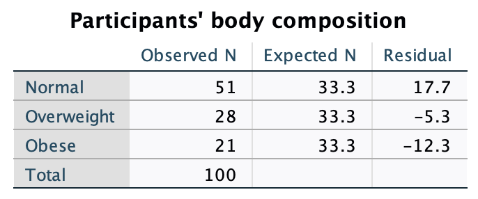

```python
img = os.path.join(path, 'static/images/chisquare/spss3.png')
Image(filename=img, width=400)
```

**Observed Frequency Table.**

- The first output provides frequencies for each category in the categorical variable.
- We see that the expected frequencies is 33.3 for each category.
- Also note that each cell for the Observed N and Expected N columns has values greater than 5, which was one of our key assumptions.

**Model Fit.**

- This table also helps us understand our model and establishes how our actual numbers (observed frequencies) per category differs from the hypothesized (expected frequencies).
- The last column `Residual` gives us this difference.
- The residual is defined as:  
  \(Residual\ =\ Observed\ N\ -\ Expected N \).
- We see that we had extra cases in the normal group and lower cases in both the overweight and obese groups
- A smaller residual indicates a better model "fit".
- The next table will summarize the actual Chi-square goodness-of-fit test, which will tells us if there is significance results, or if we accept our Null Hypothesis.

### Step 4: Interpret Results.

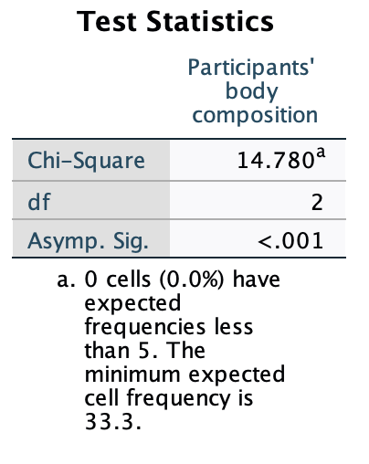

```python
img = os.path.join(path, 'static/images/chisquare/spss4.png')
Image(filename=img, width=200)
```

# Graphical Overview of \(\chi^{2} \) Goodness-of-Fit Test for Association

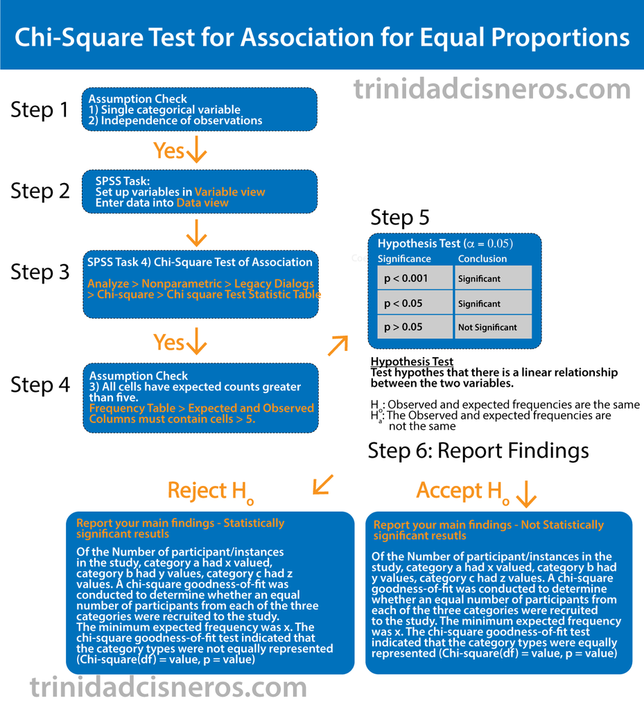

```python
img = os.path.join(path, 'static/images/chisquare/spss5.png')
Image(filename=img, width=700)
```